# PWM Enrichment of miRNA

Mark E. Pepin | MD/PhD Trainee

6/5/2018

# Identifying Putative Nrf2 Binding Sites

In order to identify the response elements likely targeted by Nfe2l2 (Nrf2) we used the position-weighted matrix (PWM) generated by Brochley *et al.* We scanned the *mus musculus* genome (mm10) for all Nrf2 (Nfe2l2) response elements using the Nfe2l2 PWM via PWMScan (Ambrosini 2018); this process identified 80,756 Nrf2 response elements throughout the mouse genome. These genomic coordinates were then used to determine which differentially-expressed miRNA are likely under the control of Nrf2 based on the presents of Antioxidant Response Elements upstream of the miRNA coding region.

## Nfe2l2 PWM (based on Brochley *et al.*) in Transfac format

AC MA0150.2  
XX  
ID Nfe2l2  
XX DE MA0150.2 Nfe2l2 ; From JASPAR 2018  
PO A C G T  
01 278 23 103 6  
02 0 2 0 408  
03 0 0 400 10  
04 410 0 0 0  
05 14 287 74 35  
06 52 11 11 336  
07 26 315 30 39  
08 329 2 47 32  
09 3 3 404 0  
10 3 398 6 3  
11 346 13 15 36  
XX  
//

## Nfe2l2 response Element: Genomic Annotation

Once the Nfe2l2 response elements were identified, we used Hypergeometric Optimization for Motif Enrichment (HOMER) to annotate these genomic regions according to the most proximal gene. The following command was used: `annotatePeaks pwmscan_mm10_40220_40766.bed mm10 > Nfe2l2_REs.Genome.txt`.

```r
library(kableExtra)
Nfe2l2_REs_Genome <- read.delim("../1_Input/3_miRNA/Nfe2l2_REs.Genome.txt",
                                header = TRUE, sep = "\t")
Ex<-head(Nfe2l2_REs_Genome)
landscape(Ex %>% knitr::kable(
                         align="c",
                         longtable=T,
                         booktabs=T,
                         caption="Annotated Response Elements") %>%
    kable_styling(latex_options=c("striped", "repeat_header", "condensed"))
)
```

Annotated Response Elements

PeakID..cmd.annotatePeaks.pl.pwmscan_mm10_40220_40766.bed.mm10.

Chr

Start

End

Strand

Peak.Score

Focus.Ratio.Region.Size

Annotation

Detailed.Annotation

Distance.to.TSS

Nearest.PromoterID

Entrez.ID

Nearest.Unigene

Nearest.Refseq

Nearest.Ensembl

Gene.Name

Gene.Alias

Gene.Description

Gene.Type

ATGACTCAGCA-1912

chr6

82702040

82702050

1959

Intergenic

B2_Mm2|SINE|B2

-49180

NM_025882

66979

Mm.195753

NM_025882

ENSMUSG00000030042

Pole4

2400007P05Rik|5830430F06Rik

polymerase (DNA-directed), epsilon 4 (p12 subunit)

protein-coding

ATGACTCAGCA-4868

chr17

64662442

64662452

1959

intron (NM_008549, intron 6 of 21)

B2_Mm2|SINE|B2

60798

NM_008549

17158

Mm.2433

NM_008549

ENSMUSG00000024085

Man2a1

Mana-2|Mana2|Map-2

mannosidase 2, alpha 1

protein-coding

ATGACTCAGCA-1928

chr6

87853595

87853605

1959

Intergenic

Intergenic

-2494

NM_001355195

12785

Mm.290251

NM_013493

ENSMUSG00000030057

Cnbp

AA408710|Cnbp1|Znf9

cellular nucleic acid binding protein

protein-coding

ATGACTCAGCA-405

chr1

191471513

191471523

1959

Intergenic

RSINE1|SINE|B4

-6470

NR_151615

102634668

NR_151615

Gm32200

predicted gene, 32200

ncRNA

ATGACTCAGCA-1617

chr5

100753629

100753639

1959

Intergenic

MamSINE1|SINE|tRNA

-33918

NM_152803

15442

Mm.265786

NM_152803

ENSMUSG00000035273

Hpse

HSE1|Hpa|Hpr1

heparanase

protein-coding

ATGACTCAGCA-4388

chr15

36657700

36657710

1959

Intergenic

Intergenic

-48732

NM_008774

18458

Mm.371570

NM_008774

ENSMUSG00000022283

Pabpc1

PABP|Pabp1|PabpI|Pabpl1|ePAB

poly(A) binding protein, cytoplasmic 1

protein-coding

## miRNA with Proximal Nrf2 Response Elements

```r
##Annotated miRNAs (based on genomic coordinates)
miRNA_index_annotated <- read.delim("~/Box/Work/4_PhD/_Papers/Do/Nrf2 Soorappan/1_Input/3_miRNA/miRNA_index.annotated.txt",
                                    sep = "\t", header = TRUE)
##Annotated AREs (based on genomic coordinates)
Nfe2l2_REs_Genome <- read.delim("../1_Input/3_miRNA/Nfe2l2_REs.Genome.txt",
                                header = TRUE, sep = "\t")
##Differential miRNA expression (based on Tg vs. NTg)
miRNA_TG<-read.csv("../2_Output/miRNA/results_miRNA_TG.v.NTG.csv")
rownames(miRNA_TG)<-miRNA_TG$X
miRNA_TG.UP<-dplyr::filter(miRNA_TG, log2FoldChange>0, pvalue<0.05)

##Merge miRNA and Nfe2l2 based on proximal promoter location
miRNA_AREs<-merge(miRNA_index_annotated, Nfe2l2_REs_Genome, by = "Nearest.PromoterID")

##Filter to only miRNA that are differentially-induced in TG-Effect
Diff.EQ_miRNA.AREs<-merge(miRNA_AREs, miRNA_TG.UP, by.x = "PeakID..cmd.annotatePeaks.pl.miRNA_sorted.txt.mm10.",
                          by.y="X")
write.csv(Diff.EQ_miRNA.AREs, "../3_Results/DiffEq.miRNA containing proximal AREs.csv")
```

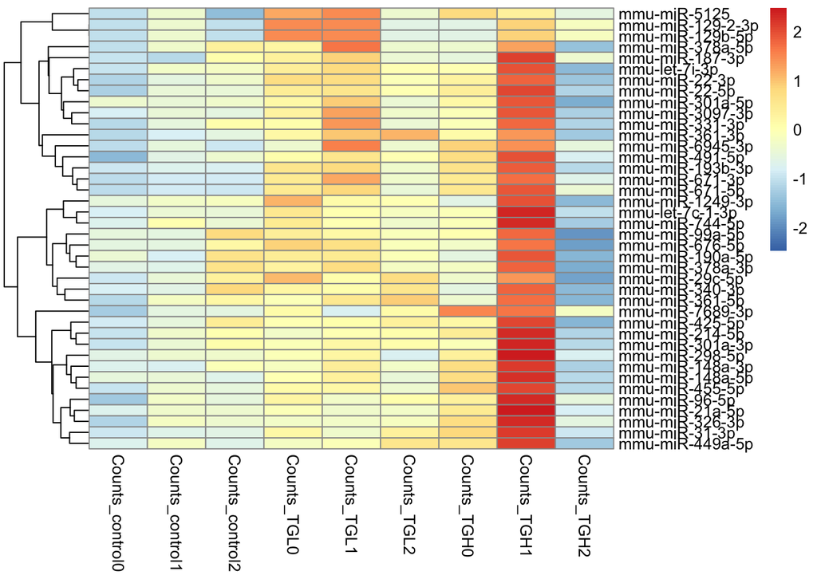

```r
library(pheatmap)
library(RColorBrewer)
#select only heatmap data
hm.data<-dplyr::select(Diff.EQ_miRNA.AREs, Counts_control0:Counts_TGH2)
hm.data$miRNA.Names<-Diff.EQ_miRNA.AREs$PeakID..cmd.annotatePeaks.pl.miRNA_sorted.txt.mm10.
hm.data<-unique(hm.data)
rownames(hm.data)<-hm.data$miRNA.Names
hm.data<-dplyr::select(hm.data, -miRNA.Names)
#write.csv(hm.data, "../1_Input/3_miRNA/miRNA_Candidates.csv")
#Import heatmap data
data_hm<-read.csv("../1_Input/3_miRNA/miRNA_Candidates.csv")
rownames(data_hm)<-data_hm$X
data_hm<-dplyr::select(data_hm, -X)
data_hm<-data.matrix(data_hm)
#data matrix of counts
pheatmap(data_hm, scale = "row", cluster_cols = FALSE)
```

```r
#plot the heatmap
paletteLength <- 100
myColor <- colorRampPalette(c("dodgerblue4", "white", "gold2"))(paletteLength)
pheatmap(data_hm,
         cluster_cols=T,
         border_color=NA,
         cluster_rows=T,
         scale = 'row',
         show_colnames = T,
         show_rownames = T,
         color = myColor,
         filename = "../3_Results/miRNA/miRNA.w.AREs_Heatmap.tiff")
```

```r
library(multiMiR)
##create miRNA list
miRNA_list<-rownames(data_hm)
miRNA_targets.all<-get_multimir(org = "mmu", mirna = miRNA_list, table = "predicted", summary = TRUE)
```

```
## Searching diana_microt ...
## Searching elmmo ...
## Searching microcosm ...
## Searching miranda ...
## Searching mirdb ...
## Searching pictar ...
## Searching pita ...
## Searching targetscan ...
```

```r
miRNA_targets.all_table<-miRNA_targets.all@data
#Load the mRNA differentially suppressed in Tg and dose-dependent on Nrf2
library(readxl)
mRNA.both.up_p01 <- read_excel("../3_Results/mRNA/mRNA.Dose_Venn.p01.xlsx",
    sheet = "BOTH_DOWN")
miRNA_Targets.annotated<-dplyr::inner_join(miRNA_targets.all_table,
                                           mRNA.both.up_p01,
                                           by=c("target_ensembl"="ensembl_gene_id"))
write.csv(miRNA_Targets.annotated,
          "../3_Results/miRNA/Predicted miRNA Targets.csv")
miR_heatmap<-read_xlsx("../3_Results/miRNA/miRNA_Targets.annotated.xlsx",
                       sheet="mRNA Targets - Dose.ALL")
rownames(miR_heatmap)<-miR_heatmap$Gene.Symbol
hm_miR.targets<-dplyr::select(miR_heatmap, -Gene.Symbol)
hm_miR.targets<-data.matrix(hm_miR.targets)
#plot the heatmap
paletteLength <- 100
myColor <- colorRampPalette(c("dodgerblue4", "white", "gold2"))(paletteLength)
pheatmap(hm_miR.targets,
         cluster_cols=T,
         border_color=NA,
         cluster_rows=T,
         scale = 'row',
         show_colnames = T,
         show_rownames = T,
         color = myColor,
         filename = "../3_Results/miRNA/Suppressed mRNA Targets of Dose-Dependent miRNA.tiff")
```

## miRNA-mRNA Network Analysis

The next component of this analysis was to determine whether upstream miRNA have overlapping predicted downstream mRNA targets. To accomplish this aim, a bipartite network analysis was created to depict (1) the differentially-expressed miRNA containing a proximal upstream Nrf2 response element, and (2) their downstream predicted mRNA targets identified via multiMiR.

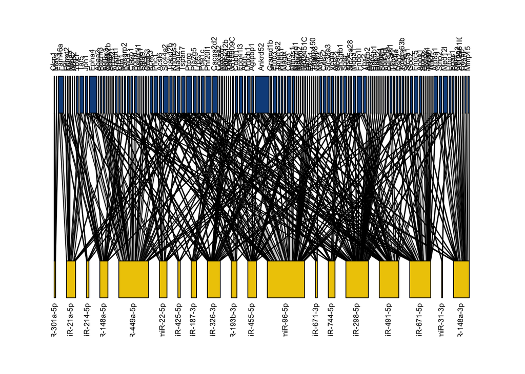

```r
library(bipartite)
#Create the occurence matrix from multiMiR output
library(readxl)
table<-read_xlsx("../3_Results/miRNA/miRNA_Targets.annotated.xlsx",
                 sheet="Dose.Dependent miRNA")
table_interactions<-dplyr::select(table, Gene.Symbol, mature_mirna_id)
matrix<-as.data.frame(table(table_interactions))
occurrence.matrix<-tidyr::spread(matrix, Gene.Symbol, Freq)
rownames(occurrence.matrix)<-occurrence.matrix$mature_mirna_id
occurrence.matrix<-dplyr::select(occurrence.matrix, -mature_mirna_id)
bipartite_in<-data.matrix(occurrence.matrix)
plotweb(bipartite_in, col.low = "gold2", col.high = "dodgerblue4", text.rot = 90)
```

# Supplemental Table: R Session Information

All packages and setting are acquired using the following command:

```r
library(kableExtra)
sinfo<-devtools::session_info()
sinfo$platform
```

```
##  setting  value
##  version  R version 3.4.2 (2017-09-28)
##  system   x86_64, darwin15.6.0
##  ui       X11
##  language (EN)
##  collate  en_US.UTF-8
##  tz       <NA>
##  date     2018-07-19
```

```r
sinfo$packages %>% kable(
                         align="c",
                         longtable=T,
                         booktabs=T,
                         caption="Packages and Required Dependencies") %>%
    kable_styling(latex_options=c("striped", "repeat_header", "condensed"))
```

Packages and Required Dependencies

package

version

date

source

AnnotationDbi

1.40.0

2017-10-31

Bioconductor

assertthat

0.2.0

2017-04-11

CRAN (R 3.4.0)

backports

1.1.2

2017-12-13

CRAN (R 3.4.3)

base

3.4.2

2017-10-04

local

bindr

0.1.1

2018-03-13

CRAN (R 3.4.2)

bindrcpp

0.2.2

2018-03-29

CRAN (R 3.4.4)

Biobase

2.38.0

2017-10-31

Bioconductor

BiocGenerics

0.24.0

2017-10-31

Bioconductor

bipartite

2.08

2017-03-31

CRAN (R 3.4.0)

bit

1.1-14

2018-05-29

CRAN (R 3.4.4)

bit64

0.9-7

2017-05-08

CRAN (R 3.4.0)

bitops

1.0-6

2013-08-17

CRAN (R 3.4.0)

blob

1.1.1

2018-03-25

CRAN (R 3.4.4)

cellranger

1.1.0

2016-07-27

CRAN (R 3.4.0)

cluster

2.0.7-1

2018-04-09

CRAN (R 3.4.4)

coda

0.19-1

2016-12-08

CRAN (R 3.4.0)

codetools

0.2-15

2016-10-05

CRAN (R 3.4.2)

colorspace

1.3-2

2016-12-14

CRAN (R 3.4.0)

compiler

3.4.2

2017-10-04

local

datasets

3.4.2

2017-10-04

local

DBI

1.0.0

2018-05-02

CRAN (R 3.4.2)

devtools

1.13.5

2018-02-18

CRAN (R 3.4.3)

digest

0.6.15

2018-01-28

CRAN (R 3.4.3)

dotCall64

0.9-5.2

2018-01-11

CRAN (R 3.4.3)

dplyr

0.7.5

2018-05-19

CRAN (R 3.4.2)

evaluate

0.10.1

2017-06-24

CRAN (R 3.4.1)

fields

9.6

2018-01-29

CRAN (R 3.4.3)

glue

1.2.0

2017-10-29

CRAN (R 3.4.2)

graphics

3.4.2

2017-10-04

local

grDevices

3.4.2

2017-10-04

local

grid

3.4.2

2017-10-04

local

gtable

0.2.0

2016-02-26

CRAN (R 3.4.0)

highr

0.7

2018-06-09

CRAN (R 3.4.2)

hms

0.4.2

2018-03-10

CRAN (R 3.4.2)

htmltools

0.3.6

2017-04-28

CRAN (R 3.4.0)

httr

1.3.1

2017-08-20

CRAN (R 3.4.1)

igraph

1.2.1

2018-03-10

CRAN (R 3.4.4)

IRanges

2.12.0

2017-10-31

Bioconductor

kableExtra

0.9.0

2018-05-21

CRAN (R 3.4.2)

knitr

1.20

2018-02-20

CRAN (R 3.4.3)

lattice

0.20-35

2017-03-25

CRAN (R 3.4.2)

magrittr

1.5

2014-11-22

CRAN (R 3.4.0)

maps

3.3.0

2018-04-03

CRAN (R 3.4.4)

MASS

7.3-50

2018-04-30

CRAN (R 3.4.2)

Matrix

1.2-14

2018-04-09

CRAN (R 3.4.4)

memoise

1.1.0

2017-04-21

CRAN (R 3.4.0)

methods

3.4.2

2017-10-04

local

mgcv

1.8-23

2018-01-15

CRAN (R 3.4.3)

multiMiR

1.1.0

2018-02-10

Bioconductor

munsell

0.5.0

2018-06-12

CRAN (R 3.4.2)

network

1.13.0.1

2018-04-02

CRAN (R 3.4.4)

nlme

3.1-137

2018-04-07

CRAN (R 3.4.4)

parallel

3.4.2

2017-10-04

local

permute

0.9-4

2016-09-09

CRAN (R 3.4.0)

pheatmap

1.0.10

2018-05-19

CRAN (R 3.4.2)

pillar

1.2.3

2018-05-25

CRAN (R 3.4.4)

pkgconfig

2.0.1

2017-03-21

CRAN (R 3.4.0)

plyr

1.8.4

2016-06-08

CRAN (R 3.4.0)

purrr

0.2.5

2018-05-29

CRAN (R 3.4.4)

R6

2.2.2

2017-06-17

CRAN (R 3.4.0)

RColorBrewer

1.1-2

2014-12-07

CRAN (R 3.4.0)

Rcpp

0.12.17

2018-05-18

CRAN (R 3.4.2)

RCurl

1.95-4.10

2018-01-04

CRAN (R 3.4.3)

readr

1.1.1

2017-05-16

CRAN (R 3.4.0)

readxl

1.1.0

2018-04-20

CRAN (R 3.4.4)

rlang

0.2.1

2018-05-30

CRAN (R 3.4.4)

rmarkdown

1.10

2018-06-11

CRAN (R 3.4.2)

rprojroot

1.3-2

2018-01-03

CRAN (R 3.4.3)

RSQLite

2.1.1

2018-05-06

CRAN (R 3.4.2)

rstudioapi

0.7

2017-09-07

CRAN (R 3.4.1)

rvest

0.3.2

2016-06-17

CRAN (R 3.4.0)

S4Vectors

0.16.0

2017-10-31

Bioconductor

scales

0.5.0

2017-08-24

CRAN (R 3.4.1)

sna

2.4

2016-08-08

CRAN (R 3.4.0)

spam

2.1-4

2018-04-12

CRAN (R 3.4.4)

statnet.common

4.1.2

2018-06-05

CRAN (R 3.4.2)

stats

3.4.2

2017-10-04

local

stats4

3.4.2

2017-10-04

local

stringi

1.2.3

2018-06-12

CRAN (R 3.4.2)

stringr

1.3.1

2018-05-10

CRAN (R 3.4.2)

tibble

1.4.2

2018-01-22

CRAN (R 3.4.3)

tidyr

0.8.1

2018-05-18

CRAN (R 3.4.2)

tidyselect

0.2.4

2018-02-26

CRAN (R 3.4.3)

tools

3.4.2

2017-10-04

local

utils

3.4.2

2017-10-04

local

vegan

2.5-2

2018-05-17

CRAN (R 3.4.4)

viridisLite

0.3.0

2018-02-01

CRAN (R 3.4.2)

withr

2.1.2

2018-03-15

CRAN (R 3.4.4)

XML

3.98-1.11

2018-04-16

CRAN (R 3.4.4)

xml2

1.2.0

2018-01-24

CRAN (R 3.4.3)

yaml

2.1.19

2018-05-01

CRAN (R 3.4.2)